# Creating Linear Regression Matrices from Segment data

James Dalgleish

July 25, 2018

From our previous work, we created a small input matrix, with segmented 1Mb regions as our row labels and with sample names from TARGET data as our column labels. We can read that in using the following code:

```r
nbl_input_matrix[1:5,1:5]
```

```
##                      PASEGA   PASRFS   PARHYL   PARVME PATGJU
## chr1_1_1000000         0.77 1.226667 0.990000 1.304444   1.09
## chr1_1000001_2000000   0.77 1.000000 1.053333 1.180000   1.09
## chr1_2000001_3000000   0.77 1.000000 0.850000 1.000000   1.09
## chr1_3000001_4000000   0.77 1.000000 0.850000 1.000000   1.09
## chr1_4000001_5000000   0.77 1.000000 0.850000 1.000000   1.09
```

```r
library(parallel)
nbl_slurm_object_test_zero_removed<-calcVecLMs(bin_data =as.data.frame(t(nbl_input_matrix[which(rowSds(as.matrix(nbl_input_matrix))!=0.0),])),use_slurm = T,n_nodes = 975,memory_per_node = "32g",walltime = "04:00:00",cpus_on_each_node = 2,job_finished = F,slurmjob = NULL)
```

Saving the slurm object is essential as it will be required when you retrieve your results.

```r
saveRDS(nbl_slurm_object_test_zero_removed,"nbl_slurm_object_test_zero_removed.rds")
```

Retrieving the data is as simple as using rslurm::get_slurm_out() on the saved slurm object and coercing it into a matrix with the original number of columns. The slurm object must have been read with readRDS() previously or done in the same session.

```r
library(matrixStats)
nbl_result_matrix<-matrix(as.numeric(unlist( get_slurm_out(nbl_slurm_object_test_zero_removed))),ncol=ncol(as.data.frame(t(nbl_input_matrix[which(rowSds(as.matrix(nbl_input_matrix))!=0.0),])) ) )

saveRDS(nbl_result_matrix,"nbl_result_matrix_full.rds")
```

```r
nbl_result_matrix[1:5,1:5]
```

```
##          [,1]       [,2]       [,3]       [,4]       [,5]
## [1,]      Inf   4.766959   3.743363   3.800939   3.800939
## [2,] 4.766959        Inf 199.883186 176.388907 176.388907
## [3,] 3.743363 199.883186        Inf 299.519384 299.519384
## [4,] 3.800939 176.388907 299.519384        Inf        Inf
## [5,] 3.800939 176.388907 299.519384        Inf        Inf
```

You’ll notice that there are no signs in this matrix (they’re just negative log p-values, which are always positive). We’ll have to assign signs by the correlation matrix next, then we will chunk the large matrix into smaller, flattened matrices that the shiny app can handle. For lower capacity machines/clusters, an alternative may be using the cor function.

In order to perfrom sign correction,fix the “Inf values” to a viewable value, and restore column and row names, postProcessLinRegMatrix() can be applied, yielding a final full matrix of the entire genome (Chr1->ChrX on both Axes). 300 has been used, although something a bit smaller will reduce saturation issues depending on the disparity between the lowest values in the matrix and 300. We’ll plot the result below, using complexheatmap and a custom designed function that takes large asymmetric distributions of values and pushes them into the [0,1] colorspace with white at 0.5, corresponding to zero, values between 0 and 0.5 corresponding to negative values, and values from 0.5 to 1 corresponding to positive values (signedRescale).

```r
nbl_result_matrix[1:5,1:5]
```

```
##          [,1]       [,2]       [,3]       [,4]       [,5]
## [1,]      Inf   4.766959   3.743363   3.800939   3.800939
## [2,] 4.766959        Inf 199.883186 176.388907 176.388907
## [3,] 3.743363 199.883186        Inf 299.519384 299.519384
## [4,] 3.800939 176.388907 299.519384        Inf        Inf
## [5,] 3.800939 176.388907 299.519384        Inf        Inf
```

```r
nbl_result_matrix_sign_corrected<-postProcessLinRegMatrix(input_matrix = nbl_input_matrix,LM_mat = nbl_result_matrix,cor_type = "pearson",inf_replacement_val = 300)
```

```r
nbl_result_matrix_sign_corrected[1:5,1:5]
```

```
##                      chr1_1_1000000 chr1_1000001_2000000
## chr1_1_1000000           300.000000             4.766959
## chr1_1000001_2000000       4.766959           300.000000
## chr1_2000001_3000000       3.743363           199.883186
## chr1_3000001_4000000       3.800939           176.388907
## chr1_4000001_5000000       3.800939           176.388907
##                      chr1_2000001_3000000 chr1_3000001_4000000
## chr1_1_1000000                   3.743363             3.800939
## chr1_1000001_2000000           199.883186           176.388907
## chr1_2000001_3000000           300.000000           299.519384
## chr1_3000001_4000000           299.519384           300.000000
## chr1_4000001_5000000           299.519384           300.000000
##                      chr1_4000001_5000000
## chr1_1_1000000                   3.800939
## chr1_1000001_2000000           176.388907
## chr1_2000001_3000000           299.519384
## chr1_3000001_4000000           300.000000
## chr1_4000001_5000000           300.000000
```

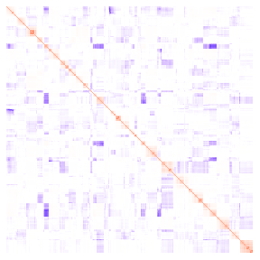

```r
ComplexHeatmap::Heatmap(signedRescale(as.matrix(nbl_result_matrix_sign_corrected)),col = circlize::colorRamp2(c(0,0.5,1),c("blue","white","red")),cluster_rows = F,cluster_columns = F,show_heatmap_legend = F,show_column_names = F,show_row_names = F)
```

Finally, the whole genome matrix is too big to plot interactively without crashing most browsers using the plotly package. We’ll need to break things apart a bit. A final function will write chromosomal pair heatmaps to disk with genes from ensembl (hg19 coordinates) in encoded for each square in the matrix.

```r
if(!dir.exists("nbl_matrix_set")){dir.create("nbl_matrix_set")}
#setwd("nbl_matrix_set")
doMC::registerDoMC()
createChromosomalMatrixSet(whole_genome_mat=nbl_result_matrix_sign_corrected,output_dir="nbl_matrix_set",prefix="nbl_")
```

```r
list.files("nbl_matrix_set")
```

```
##   [1] "chr1_chr1_nbl_sample_matched_unrescaled.RData"
##   [2] "chr1_chr10_nbl_sample_matched_unrescaled.RData"
##   [3] "chr1_chr11_nbl_sample_matched_unrescaled.RData"
##   [4] "chr1_chr12_nbl_sample_matched_unrescaled.RData"
##   [5] "chr1_chr13_nbl_sample_matched_unrescaled.RData"
##   [6] "chr1_chr14_nbl_sample_matched_unrescaled.RData"
##   [7] "chr1_chr15_nbl_sample_matched_unrescaled.RData"
##   [8] "chr1_chr16_nbl_sample_matched_unrescaled.RData"
##   [9] "chr1_chr17_nbl_sample_matched_unrescaled.RData"
##  [10] "chr1_chr18_nbl_sample_matched_unrescaled.RData"
##  [11] "chr1_chr19_nbl_sample_matched_unrescaled.RData"
##  [12] "chr1_chr2_nbl_sample_matched_unrescaled.RData"
##  [13] "chr1_chr20_nbl_sample_matched_unrescaled.RData"
##  [14] "chr1_chr21_nbl_sample_matched_unrescaled.RData"
##  [15] "chr1_chr22_nbl_sample_matched_unrescaled.RData"
```

[output cut: 514 more lines]

There should be 529 of these particular files upon running the code. If there are not, don’t hesitate to run the code again. It can happen on a cluster. It is built to detect when chromosomal matrix is already written to disk.